# Repdata Assignment #1

```r
library(plyr)
library(dplyr)
```

```r
library(ggplot2)
library(lattice)
```

### The Data

From the assignment’s description:

*This assignment makes use of data from a personal activity monitoring device. This device collects data at 5 minute intervals through out the day. The data consists of two months of data from an anonymous individual collected during the months of October and November, 2012 and include the number of steps taken in 5 minute intervals each day.*

*The variables included in this dataset are:*

- **steps**: *Number of steps taking in a 5-minute interval (missing values are coded as NA)*
- **date**: *The date on which the measurement was taken in YYYY-MM-DD format*
- **interval**: *Identifier for the 5-minute interval in which measurement was taken*

*The dataset is stored in a comma-separated-value (CSV) file and there are a total of 17,568 observations in this dataset.*

```r
ActivityData <- read.csv("./activity.csv")
ActivityData$day <- weekdays(as.Date(ActivityData$date))
str(ActivityData)
```

```
## 'data.frame':    17568 obs. of  4 variables:
##  $ steps   : int  NA NA NA NA NA NA NA NA NA NA ...
##  $ date    : Factor w/ 61 levels "2012-10-01","2012-10-02",..: 1 1 1 1 1 1 1 1 1 1 ...
##  $ interval: int  0 5 10 15 20 25 30 35 40 45 ...
##  $ day     : chr  "Monday" "Monday" "Monday" "Monday" ...
```

```r
summary(ActivityData)
```

```
##      steps                date          interval          day
##  Min.   :  0.00   2012-10-01:  288   Min.   :   0.0   Length:17568
##  1st Qu.:  0.00   2012-10-02:  288   1st Qu.: 588.8   Class :character
##  Median :  0.00   2012-10-03:  288   Median :1177.5   Mode  :character
##  Mean   : 37.38   2012-10-04:  288   Mean   :1177.5
##  3rd Qu.: 12.00   2012-10-05:  288   3rd Qu.:1766.2
##  Max.   :806.00   2012-10-06:  288   Max.   :2355.0
##  NA's   :2304     (Other)   :15840
```

### Mean total number of steps per day

```r
TotSteps <- sapply(split(ActivityData$steps, ActivityData$date), sum)
mean(TotSteps, na.rm=TRUE)
```

```
## [1] 10766.19
```

```
## stat_bin: binwidth defaulted to range/30. Use 'binwidth = x' to adjust this.
```

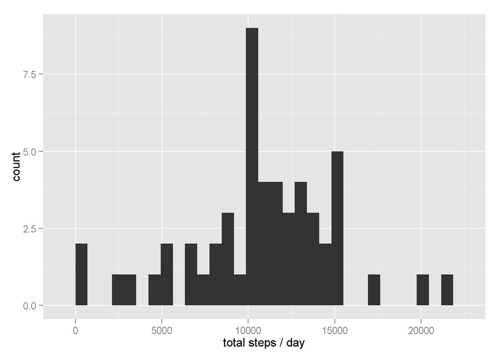

```r
qplot(TotSteps, xlab="total steps / day")
```

### Average daily acivty pattern

The five minute interval containing the most steps averaged across all days is 835. And belw the calculation here’s a graph of all the intervals with their respective numbers of steps.

```r
AverageSteps <- sapply(split(ActivityData$steps, ActivityData$interval), mean, na.rm = TRUE)
names(AverageSteps)[AverageSteps == max(AverageSteps)]
```

```
## [1] "835"
```

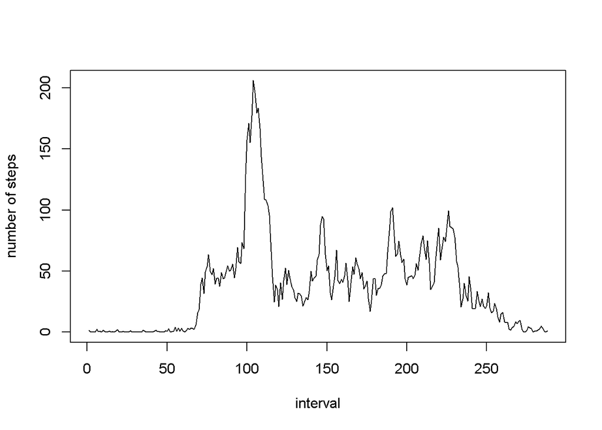

```r
plot(AverageSteps, type = "l", xlab = "interval", ylab = "number of steps")
```

### Missing values

The number of missing values is:

```r
sum(is.na(ActivityData$steps))
```

```
## [1] 2304
```

We fill them up wih the corresponding means. And check on our work.

```r
ActivityDataV2 <- ActivityData
for (i in 1:nrow(ActivityDataV2)) {
    if (is.na(ActivityDataV2[i, "steps"])) {
        interval = as.character(ActivityDataV2[i, "interval"])
        ActivityDataV2[i, "steps"] = AverageSteps[interval]
    }
}
sum(is.na(ActivityDataV2$steps))
```

```
## [1] 0
```

### Weekdays vs weekends

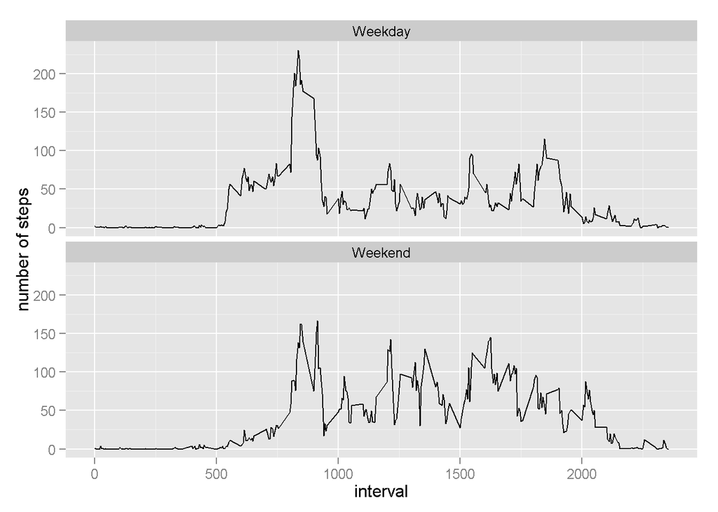

```r
ActivityDataV2$wkday <- ifelse(ActivityDataV2$day %in% c("Saturday", "Sunday"),"Weekend", "Weekday")
WeekVersusEnd <- aggregate(steps ~ interval + wkday, ActivityDataV2, mean)
ggplot(WeekVersusEnd, aes(x=interval,y=steps)) +
geom_line(color="black",size=0.5) +
facet_wrap(~wkday, nrow=2, ncol=1) +
labs(x="interval",y="number of steps")
```